# Preregistration ESM analysis code

Anu Hiekkaranta & Koen Derks

In this document we will describe the planned analyses for the experiment. To illustrate these analyses we will use an example data set, which is to be replaced when data collection has ended.

```r
# Clear the workspace
rm(list=ls())

# Load the required packages
library(lme4)               # For frequentist hierarchical modeling
library(lmerTest)         # For testing effect in lme4
library(brms)           # For Bayesian hierarchical modeling
library(bayesplot)      # For plotting the samples
library(viridis)
library(ggmcmc)
library(ggthemes)
library(ggridges)
library(gridExtra)
library(mcmcplots)

# Set a global seed to make the results reproducible
seed <- 120495

# Specify the algorithmic options for `lme4`
ctrl <- lme4::lmerControl(optimizer = "optimx", calc.derivs = FALSE,
                          optCtrl = list(method = "nlminb", starttests = FALSE, kkt = FALSE))

# Specify the algorithmic options for `brms`
warmup          <- 2000          # Number of samples to discard before saving
iterations      <- 5000          # Number of total samples
chains          <- 4             # Number of individual sampling chains
cores           <- 4             # Number of CPU cores to use
max_treedepth   <- 10            # Maximum allowed tree depth
adapt_delta     <- 0.999         # Target acceptance rate of samples

# Helper functions for data manipulation and plotting
.scaleNumericData <- function(x, center = TRUE, scale = TRUE) {
  if (nrow(x) == 0)
    return(x)
  idx <- sapply(x, is.numeric)
  x[, idx] <- scale(x[, idx, drop = FALSE], center, scale)
  attr(x, which = "scaled:center") <- NULL
  attr(x, which = "scaled:scale")  <- NULL
  return(x)
}

# Create a function to visualize the posterior distributions of the fixed effects
.plotPopulationEffectDensities <- function(fit, title, xmin, xmax, warmup){
  colorValues <- c("darkorange1", "gold", "khaki4", "turquoise4", "mediumpurple3")
  mtfit <- ggs(fit)
  sumFixed <- summary(fit)$fixed
  parameters <- paste0("b_", rownames(sumFixed))
  plotData <- filter(mtfit, Parameter %in% parameters, Iteration > warmup)
  plotData$Parameter <- factor(plotData$Parameter, levels = parameters)
  p <- ggplot(plotData,
              aes(x = value, fill = Parameter)) +
              geom_density(alpha = .5) +
              labs(title = title) +
              geom_segment(x = 0, xend = 0, y = 0, yend = Inf, colour = "red", linetype = "solid", size = 0.5) +
              scale_x_continuous(name   = "Standardized value", limits = c(xmin, xmax)) +
              scale_y_continuous(name = "Density") +
              geom_segment(x = sumFixed[1,3], xend = sumFixed[1,3], y = 0, yend = Inf,
                           col = colorValues[1], linetype = 2) +
              geom_segment(x = sumFixed[1,4], xend = sumFixed[1,4], y = 0, yend = Inf,
                           col = colorValues[1], linetype = 2) +
              geom_segment(x = sumFixed[2,3], xend = sumFixed[2,3], y = 0, yend = Inf,
                           col = colorValues[2], linetype = 2) +
              geom_segment(x = sumFixed[2,4], xend = sumFixed[2,4], y = 0, yend = Inf,
                           col = colorValues[2], linetype = 2) +
              geom_segment(x = sumFixed[3,3], xend = sumFixed[3,3], y = 0, yend = Inf,
                           col = colorValues[3], linetype = 2) +
              geom_segment(x = sumFixed[3,4], xend = sumFixed[3,4], y = 0, yend = Inf,
                           col = colorValues[3], linetype = 2) +
              geom_segment(x = sumFixed[4,3], xend = sumFixed[4,3], y = 0, yend = Inf,
                           col = colorValues[4], linetype = 2) +
              geom_segment(x = sumFixed[4,4], xend = sumFixed[4,4], y = 0, yend = Inf,
                           col = colorValues[4], linetype = 2) +
              geom_segment(x = sumFixed[5,3], xend = sumFixed[5,3], y = 0, yend = Inf,
                           col = colorValues[5], linetype = 2) +
              geom_segment(x = sumFixed[5,4], xend = sumFixed[5,4], y = 0, yend = Inf,
                           col = colorValues[5], linetype = 2) +
              geom_segment(x = xmin, xend = xmax, y = -Inf, yend = -Inf) +
              geom_segment(x = -Inf, xend = -Inf, y = 0, yend = 20) +
              scale_fill_manual(name  = 'Parameters',
                               values = colorValues,
                               labels = c(expression(gamma['00']),
                                          expression(gamma['10']),
                                          expression(gamma['20']),
                                          expression(gamma['30']),
                                          expression(gamma['40']))) +
            theme_minimal() +
      theme(panel.grid = element_blank(), axis.ticks = element_line())
  return(p)
}

# Create a function to visualize the non-informed and informed prior and posterior distributions
.plotInfluenceOfPriors <- function(coef, fit_f, fit_ni, fit_i, title, priors, xmin, xmax, ymax){

  lmeEst <- summary(fit1_f)$coefficients[coef, "Estimate"]
  sumFixedni <- summary(fit1_bni)$fixed
  sumFixedi <- summary(fit1_bi)$fixed

  posterior1 <- posterior_samples(fit1_bni, pars = paste0("b_", coef))
  posterior2 <- posterior_samples(fit1_bi, pars = paste0("b_", coef))
  posterior1.2 <- bind_rows("prior 1" = gather(posterior1), "prior 2" = gather(posterior2), .id = "id")

  colorValues <- c("skyblue", "seagreen")
  row <- which(rownames(sumFixedi) == coef)

  p <- ggplot(data = posterior1.2,
        mapping = aes(x = value, fill = id, colour = key, linetype = key, alpha = key)) +
        geom_segment(x = 0, xend = 0, y = 0, yend = Inf, colour = "red",
                     linetype = "solid", alpha = 1, size = 0.5) +
        geom_segment(x = lmeEst, xend = lmeEst, y = 0, yend = Inf, colour = "black",
                     linetype = "dashed", alpha = 1, size = 0.5) +
        annotate(geom = "text", x = lmeEst, y = ymax - 0.2, hjust = -0.1,
                 label = paste0("LME estimate: ", round(lmeEst, 3)),
                 col = "black", family = theme_get()$text[["family"]], size = theme_get()$text[["size"]]/3.5,
                 fontface="italic") +
        geom_density(size = 0.75) +
        scale_x_continuous(name = "Standardized value", limits = c(xmin, xmax)) +
        scale_y_continuous(name = "Density", limits = c(0, ymax), breaks = pretty(c(0, ymax))) +
        scale_fill_manual(name = "Densities", values = colorValues, labels = priors) +
        scale_colour_manual(name = 'Posterior/Prior', values = c("black","red"), labels = c("posterior", "prior"))+
        scale_linetype_manual(name ='Posterior/Prior', values = c("solid","dotted"), labels = c("posterior", "prior"))+
        scale_alpha_discrete(name = 'Posterior/Prior', range  = c(.7,.3), labels = c("posterior", "prior"))+
        labs(title = title,
             subtitle = "2 different densities of priors and posteriors and the LME estimate") +
        geom_segment(x = xmin, xend = xmax, y = -Inf, yend = -Inf, colour = "black", linetype = "solid", alpha = 1) +
        geom_segment(x = -Inf, xend = -Inf, y = 0, yend = ymax, colour = "black", linetype = "solid", alpha = 1) +
        geom_segment(x = sumFixedni[row,3], xend = sumFixedni[row,3], y = 0, yend = Inf,
                     col = colorValues[1], linetype = "dashed", alpha = 1) +
        geom_segment(x = sumFixedni[row,4], xend = sumFixedni[row,4], y = 0, yend = Inf,
                     col = colorValues[1], linetype = "dashed", alpha = 1) +
        geom_segment(x = sumFixedi[row,3], xend = sumFixedi[row,3], y = 0, yend = Inf,
                     col = colorValues[2], linetype = "dashed", alpha = 1) +
        geom_segment(x = sumFixedi[row,4], xend = sumFixedi[row,4], y = 0, yend = Inf,
                     col = colorValues[2], linetype = "dashed", alpha = 1) +
        theme_minimal() +
        theme(panel.grid = element_blank(), axis.ticks = element_line())
  return(p)
}

# Create a function to visualize the posterior distribution of the random slopes standard deviation
.plotPosteriorModelSD <- function(fit, var, title, xmin, xmax, color){
  parName <- paste0("sd_ID__", var)
  sumRandom <- summary(fit)$random$ID
  p <- ggplot(filter(ggs(fit), Parameter == parName, Iteration > warmup), aes(x = value)) +
      geom_segment(x = 0, xend = 0, y = Inf, yend = 0, col = "red") +
      geom_segment(x = sumRandom[2,1], xend = sumRandom[2,1],
                   y = Inf, yend = 0, col = "blue") +
      geom_segment(x = sumRandom[2,3], xend = sumRandom[2,3],
                   y = Inf, yend = 0, col = "blue", linetype = 2) +
      geom_segment(x = sumRandom[2,4], xend = sumRandom[2,4],
                         y = Inf, yend = 0, col = "blue", linetype = 2) +
      geom_density(fill  = color, alpha = .05) +
      scale_x_continuous(name = "Standardized value", limits = c(xmin, xmax), breaks = pretty(c(xmin, xmax, 0))) +
      scale_y_continuous(name = "Density") +
      labs(title = title) +
      geom_segment(x = xmin, xend = xmax, y = -Inf, yend = -Inf) +
      geom_segment(x = -Inf, xend = -Inf, y = 0, yend = 20) +
      theme_minimal() +
      theme(panel.grid = element_blank(), axis.ticks = element_line())
  return(p)
}

# Create a function to visualize the individual posterior distributions of the random slopes
.plotIndividualDifferences <- function(independent, dependent, fit, title, subtitle, xmin, xmax){

  samples <- posterior_samples(fit, pars = paste0(independent, "|ID"))
  samples <- as_tibble(t(samples[, 7:9]))

  col <- which(colnames(dataset) == dependent)
  dep <- aggregate(dataset[, col], by = list(ID = dataset$ID), FUN = mean, na.rm = T)
  colnames(dep) <- c("ID", dependent)
  dep <- dep[complete.cases(dep), ]

  plotdata <- cbind(dep, samples) %>%
  gather(key = "key", value = "value", -as.character(dependent), -ID) %>%
    group_by(ID) %>%
    mutate(meanperid = mean(value))%>%
    ungroup()

  plotdata$ID <- factor(plotdata$ID, levels = levels(plotdata$ID))

  p <- ggplot() +
        ggridges::geom_density_ridges(data  = plotdata,
                                      aes(x = value, y = reorder(as.factor(ID), meanperid),
                                          height = ..density.., fill = ID, scale = 3, alpha = .6),
                                          scale = 3, alpha = .6) +
        geom_point(data = summarise(group_by(plotdata, ID), meand = mean(meanperid)),
                    aes(x = meand, y = ID), col = "red") +
        scale_x_continuous(name = "Value", limits = c(xmin, xmax), breaks = pretty(c(xmin, xmax))) +
        scale_y_discrete(name = "ID") +
        viridis::scale_fill_viridis(discrete = TRUE) +
        labs(title = title,
             subtitle = subtitle) +
        annotate(geom = "text", x = 1.5, y = 0.75, label = "Grand mean", col = "red",
                 family = theme_get()$text[["family"]], size = theme_get()$text[["size"]]/3, fontface = "italic") +
        geom_vline(xintercept = 0, col = "red") +
        theme_minimal() +
        theme(panel.grid = element_blank(), axis.ticks = element_line(), axis.line.x = element_line())
  return(p)
}

# Apply the chosen seed globally
set.seed(seed)
```

# 1 Data

The data set contains the following variables:

- $ID$: The identification number of the participant,
- $INEG$: The intensity of daily negative events experienced by the participant,
- $IPOS$: The intensity of daily positive events experienced by the participant,
- $RUM$: The intensity of ruminating experienced by the participant,
- $SAV$: The intensity of savoring experienced by the participant,
- $SHAREN$: The intensity by which the participant shared negative events,
- $SHAREP$: The intensity by which the participant shared positive events,
- $PP$: The psychopathology score of the participant,
- $GEN$: The gender of the participant,
- $AGE$: The age of the participant.

```r
# Start by reading in the data set
fulldata <- read.csv(file = "https://raw.githubusercontent.com/koenderks/preregistrationESM/master/dataset.csv", sep = ",", fileEncoding="UTF-8-BOM")

# Select only the columns that are required for these analyses
fulldata <- fulldata[, c("ID", "INEG", "IPOS", "RUM", "SAV", "SHAREN", "SHAREP", "PP", "GEN", "AGE", "DAY", "C19SE", "C19SS")]

# Make factor variables for ID, DAY, and GEN
fulldata$ID   <- as.factor(fulldata$ID)
fulldata$DAY  <- as.factor(fulldata$DAY)
fulldata$GEN  <- as.factor(fulldata$GEN)

# Standardize the other numeric variables
fulldata <- .scaleNumericData(fulldata)

# Inspect the data set
head(fulldata)
```

|  | ID | INEG | IPOS | RUM | SAV | SHAREN | SHAREP | PP | GEN | AGE | DAY | C19SE | C19SS |
| --- | --- | --- | --- | --- | --- | --- | --- | --- | --- | --- | --- | --- | --- |
| 1 | 1 | NA | -2.9461587 | NA | 1.3490885 | NA | -1.6378764 | 0.7450846 | 2 | 0.5251256 | 1 | -0.2285819 | -1.057608 |
| 2 | 1 | -1.4794432 | NA | -0.05135985 | NA | -1.8183513 | NA | 0.7450846 | 2 | 0.5251256 | 1 | -0.2285819 | -1.057608 |
| 3 | 1 | 0.5173856 | NA | 0.96727711 | NA | -1.2714672 | NA | 0.7450846 | 2 | 0.5251256 | 1 | -0.2285819 | -1.057608 |
| 4 | 1 | -1.4794432 | NA | 0.96727711 | NA | -0.7245831 | NA | 0.7450846 | 2 | 0.5251256 | 1 | -0.2285819 | -1.057608 |
| 5 | 1 | NA | -1.7180176 | NA | -0.8630428 | NA | -1.1442889 | 0.7450846 | 2 | 0.5251256 | 1 | -0.2285819 | -1.057608 |
| 6 | 1 | NA | 0.7382646 | NA | -0.8630428 | NA | -0.1571138 | 0.7450846 | 2 | 0.5251256 | 1 | -0.2285819 | -1.057608 |

# 2 Hypotheses

The expected relationships in the data are the following:

# 3 Confirmatory Analyses

Below we will outline six models that will be use to find out to what degree the data contain support for any of the specified expectations.

## 3.1 Model 1: Sharing negative events

Model 1 investigates the following expectations:

- Expectation 1: Talking more about daily negative events is associated with lower psychopathology,
- Expectation 6: Intensity of daily negative events is positively associated with sharing.

The regression formula for this model is:

$$SHAREN_{ij} = \gamma_{00} + \gamma_{10} \cdot PP_{ij} + \gamma_{20} \cdot AGE_{ij} + \gamma_{30} \cdot GEN_{{M}_{ij}} + \gamma_{40} \cdot INEG_{ij} + u_{4j} \cdot INEG_{ij} + u_{0j} + \epsilon_{ij},$$

in which observation $i$ from participant $j$ is predicted by a population-level intercept and coefficients for $PP$, $AGE$, $GEN_M$ and $INEG$ and a person-level intercept and random coefficient for $INEG$.

Therefore, to investigate expectation 1 and expectation 6, we test the following hypotheses respectively:

- Hypothesis 1: $H_0: \gamma_{10} \geq 0$ vs. $H_1: \gamma_{10} < 0$,
- Hypothesis 6: $H_0: \gamma_{40} \leq 0$ vs. $H_1: \gamma_{40} > 0$.

```r
# Hypothesis 1:
# Talking more about daily negative events is associated with lower psychopathology
# -> Negative population effect (PP < 0).
#
# Hypothesis 6:
# Intensity of daily negative events is positively associated with sharing
# -> Positive population effect (INEG > 0).
#
# Model:
# SHAREN ~ 1 + PP + AGE + GEN + INEG + (1 + INEG|ID)

model1f <- SHAREN ~ 1 + PP + AGE + GEN + INEG + (1 + INEG|ID)
model1b <- SHAREN ~ 0 + Intercept + PP + AGE + GEN + INEG + (1 + INEG|ID)
```

```r
# Remove NA values from the data set
dataset <- fulldata[!is.na(fulldata$INEG), ]
```

### 3.1.1 Data visualization

First we visualize the data to get a better impression of the effects under investigation.

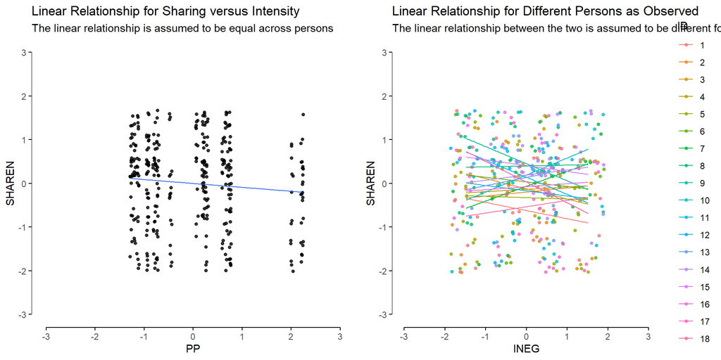

```r
p1 <- ggplot(data = dataset, aes(x = PP, y = SHAREN)) +
        geom_point(size = 1.2, alpha = 0.8, position = "jitter") +
        geom_smooth(method = lm, se = FALSE, size = .5, alpha = .8) +
        labs(title = "Linear Relationship for Sharing versus Intensity",
              subtitle = "The linear relationship is assumed to be equal across persons") +
        geom_segment(x = -3, xend = 3, y = -Inf, yend = -Inf, col = "black") +
        geom_segment(x = -Inf, xend = -Inf, y = -3, yend = 3, col = "black") +
        scale_y_continuous(name = "SHAREN", limits = c(-3, 3), breaks = pretty(c(-3, 3))) +
        scale_x_continuous(name = "PP", limits = c(-3, 3), breaks = pretty(c(-3, 3))) +
        theme_minimal() +
        theme(panel.grid = element_blank(), axis.ticks = element_line(), legend.position = "none")

p2 <- ggplot(data = dataset, aes(x = INEG, y = SHAREN, col = ID, group = ID)) +
        geom_point(size = 1.2, alpha = .8, position = "jitter") +
        geom_smooth(method = lm, se = FALSE, size = .5, alpha = .8) +
        labs(title = "Linear Relationship for Different Persons as Observed",
              subtitle = "The linear relationship between the two is assumed to be different for all persons") +
        geom_segment(x = -3, xend = 3, y = -Inf, yend = -Inf, col = "black") +
        geom_segment(x = -Inf, xend = -Inf, y = -3, yend = 3, col = "black") +
        scale_y_continuous(name = "SHAREN", limits = c(-3, 3), breaks = pretty(c(-3, 3))) +
        scale_x_continuous(name = "INEG", limits = c(-3, 3), breaks = pretty(c(-3, 3))) +
        theme_minimal() +
        theme(panel.grid = element_blank(), axis.ticks = element_line())
grid.arrange(p1, p2, nrow = 1)
```

### 3.1.2 Frequentist analysis

```r
fit1_f  <- lmerTest::lmer(formula = model1f, data = dataset, control = ctrl)
sum1_f  <- summary(fit1_f)
print(sum1_f)
```

```
## Linear mixed model fit by REML. t-tests use Satterthwaite's method [
## lmerModLmerTest]
## Formula: model1f
##    Data: dataset
## Control: ctrl
##
## REML criterion at convergence: 1021.4
##
## Scaled residuals:
##     Min      1Q  Median      3Q     Max
## -2.0564 -0.7334  0.1979  0.7105  1.6995
##
## Random effects:
##  Groups   Name        Variance Std.Dev. Corr
##  ID       (Intercept) 0.02551  0.1597
##           INEG        0.01416  0.1190   -0.06
##  Residual             0.95868  0.9791
## Number of obs: 357, groups:  ID, 18
##
## Fixed effects:
##             Estimate Std. Error       df t value Pr(>|t|)
## (Intercept) -0.12023    0.10793 10.41961  -1.114   0.2903
## PP          -0.17695    0.09124 11.78375  -1.939   0.0768 .
## AGE          0.07406    0.08506 11.42598   0.871   0.4018
## GEN2         0.19536    0.14619 10.97712   1.336   0.2085
## INEG        -0.03455    0.05989 15.55512  -0.577   0.5723
## ---
## Signif. codes:  0 '***' 0.001 '**' 0.01 '*' 0.05 '.' 0.1 ' ' 1
##
## Correlation of Fixed Effects:
##      (Intr) PP     AGE    GEN2
## PP    0.361
## AGE  -0.189 -0.655
## GEN2 -0.802 -0.434  0.214
## INEG -0.013 -0.021  0.025  0.003
```

##### 3.1.2.0.1 ANOVA test for removal of random effects

By removing the random effect from the model, we can inspect whether it produced a better fit.

```r
test1_f2 <- lmerTest::ranova(fit1_f)
print(test1_f2)
```

```
## ANOVA-like table for random-effects: Single term deletions
##
## Model:
## SHAREN ~ PP + AGE + GEN + INEG + (1 + INEG | ID)
##                         npar  logLik    AIC     LRT Df Pr(>Chisq)
## <none>                     9 -510.71 1039.4
## INEG in (1 + INEG | ID)    7 -511.01 1036.0 0.59856  2     0.7414
```

### 3.1.3 Bayesian analysis

For the Bayesian analysis we use two different sets of priors.

First, we specify a set of non-informative priors on top of the `brms` default priors consisting of:

$$\gamma_{00} \sim N(0, 1) \\
\gamma_{10} \sim N(0, 1) \\
\gamma_{20} \sim N(0, 1) \\
\gamma_{30} \sim N(0, 1) \\
\gamma_{40} \sim N(0, 1)$$

Second, we specify a set of informed priors on top of the `brms` default priors consisting of:

$$\gamma_{00} \sim Cauchy(-0.48, 0.85) \\
\gamma_{10} \sim N(-.26, .25) \\
\gamma_{20} \sim N(-0.01, 0.05) \\
\gamma_{30} \sim N(0.45, .12) \\
\gamma_{40} \sim N(0.48, 0.06)$$

```r
# Non-informative priors:
#
# b_Intercept ~ Normal(0, 1)
# b_Age ~ Normal(0, 1)
# b_PP ~ Normal(0, 1)
# b_GEN2 ~ Normal(0, 1)
# b_INEG ~ Normal(0, 1)

priorsni <- c(set_prior("normal(0,1)", class = "b", coef = "Intercept"),
            set_prior("normal(0,1)", class = "b", coef = "AGE"),
            set_prior("normal(0,1)", class = "b", coef = "PP"),
            set_prior("normal(0,1)", class = "b", coef = "GEN2"),
            set_prior("normal(0,1)", class = "b", coef = "INEG"))

fit1_bni <- brms::brm(formula = model1b,
                    data      = dataset,
                    inits     = "random",
                    chains    = chains,
                    cores     = cores,
                    prior     = priorsni,
                    warmup    = warmup,
                    iter      = iterations,
                    seed      = seed,
                    sample_prior = TRUE,
                    control = list(adapt_delta = adapt_delta,
                                   max_treedepth = max_treedepth),
                    save_pars = brms::save_pars(all = TRUE))

# Informed priors:
#
# b_Intercept ~ Cauchy(-0.48, 0.85)
# b_Age ~ Normal(-0.01, 0.05)
# b_PP ~ Normal(-.26,.25)
# b_GEN2 ~ Normal(0.45,.12)
# b_INEG ~ Normal(0.48,.06)

priorsi <- c(set_prior("cauchy(-.48,.85)", class = "b", coef = "Intercept"),
            set_prior("normal(-.01, .05)", class = "b", coef = "AGE"),
            set_prior("normal(-.26,.25)", class = "b", coef = "PP"),
            set_prior("normal(0.45,.12)", class = "b", coef = "GEN2"),
            set_prior("normal(0.48,.06)", class = "b", coef = "INEG"))

fit1_bi <- brms::brm(formula  = model1b,
                     data     = dataset,
                     inits    = "random",
                     chains   = chains,
                     cores    = cores,
                     prior    = priorsi,
                     warmup   = warmup,
                     iter     = iterations,
                     seed     = seed,
                     sample_prior = TRUE,
                     control = list(adapt_delta = adapt_delta,
                                    max_treedepth = max_treedepth),
                     save_pars = brms::save_pars(all = TRUE))
```

#### 3.1.3.1 Parameter estimates

##### 3.1.3.1.1 Non-informative priors

```r
sum1_bni <- summary(fit1_bni)
print(sum1_bni)
```

```
##  Family: gaussian
##   Links: mu = identity; sigma = identity
## Formula: SHAREN ~ 0 + Intercept + PP + AGE + GEN + INEG + (1 + INEG | ID)
##    Data: dataset (Number of observations: 357)
## Samples: 4 chains, each with iter = 5000; warmup = 2000; thin = 1;
##          total post-warmup samples = 12000
##
## Group-Level Effects:
## ~ID (Number of levels: 18)
##                     Estimate Est.Error l-95% CI u-95% CI Rhat Bulk_ESS Tail_ESS
## sd(Intercept)           0.17      0.10     0.01     0.39 1.00     3046     4125
## sd(INEG)                0.13      0.08     0.01     0.31 1.00     3612     4528
## cor(Intercept,INEG)    -0.03      0.55    -0.94     0.93 1.00     5438     6592
##
## Population-Level Effects:
##           Estimate Est.Error l-95% CI u-95% CI Rhat Bulk_ESS Tail_ESS
## Intercept    -0.12      0.11    -0.34     0.11 1.00     5715     6792
## PP           -0.17      0.10    -0.36     0.02 1.00     6922     6306
## AGE           0.07      0.09    -0.11     0.26 1.00     6118     6036
## GEN2          0.19      0.15    -0.12     0.49 1.00     6005     6836
## INEG         -0.03      0.06    -0.16     0.09 1.00    10001     7708
##
## Family Specific Parameters:
##       Estimate Est.Error l-95% CI u-95% CI Rhat Bulk_ESS Tail_ESS
## sigma     0.98      0.04     0.91     1.06 1.00    14199     9255
##
## Samples were drawn using sampling(NUTS). For each parameter, Bulk_ESS
## and Tail_ESS are effective sample size measures, and Rhat is the potential
## scale reduction factor on split chains (at convergence, Rhat = 1).
```

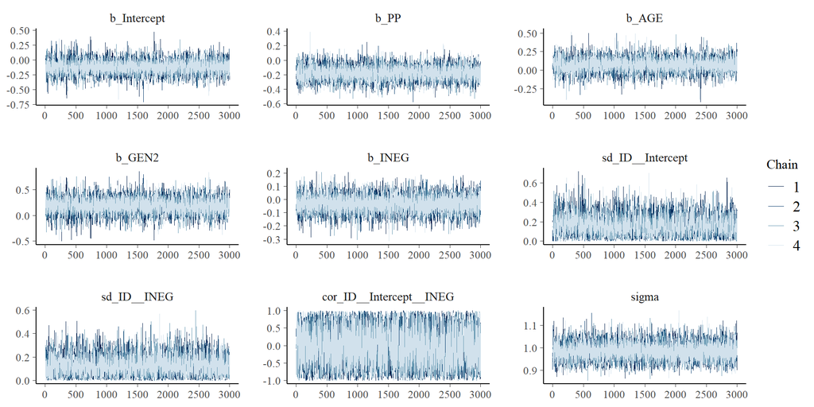

```r
mcmc_plot(fit1_bni, type = "trace")
```

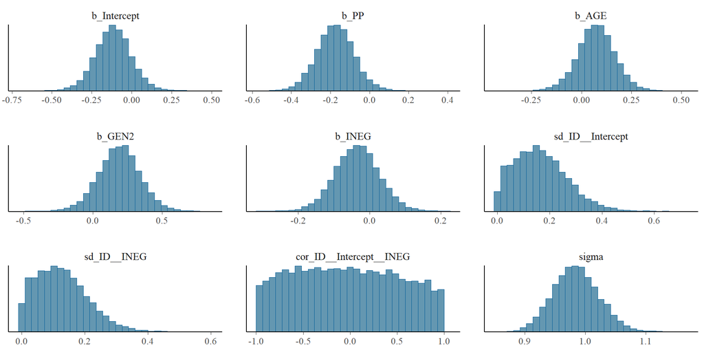

```r
mcmc_plot(fit1_bni, type = "hist")
```

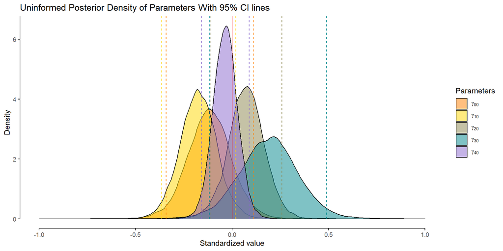

```r
.plotPopulationEffectDensities(fit1_bni, title = "Uninformed Posterior Density of Parameters With 95% CI lines",
                                xmin = -1, xmax = 1, warmup = warmup)
```

##### 3.1.3.1.2 Informed priors

```r
sum1_bi <- summary(fit1_bi, priors = TRUE)
print(sum1_bi)
```

```
##  Family: gaussian
##   Links: mu = identity; sigma = identity
## Formula: SHAREN ~ 0 + Intercept + PP + AGE + GEN + INEG + (1 + INEG | ID)
##    Data: dataset (Number of observations: 357)
## Samples: 4 chains, each with iter = 5000; warmup = 2000; thin = 1;
##          total post-warmup samples = 12000
##
## Priors:
## b_AGE ~ normal(-.01, .05)
## b_GEN2 ~ normal(0.45,.12)
## b_INEG ~ normal(0.48,.06)
## b_Intercept ~ cauchy(-.48,.85)
## b_PP ~ normal(-.26,.25)
## L ~ lkj_corr_cholesky(1)
## sd ~ student_t(3, 0, 2.5)
## sigma ~ student_t(3, 0, 2.5)
##
## Group-Level Effects:
## ~ID (Number of levels: 18)
##                     Estimate Est.Error l-95% CI u-95% CI Rhat Bulk_ESS Tail_ESS
## sd(Intercept)           0.18      0.11     0.01     0.44 1.00     2669     4834
## sd(INEG)                0.45      0.12     0.24     0.73 1.00     3687     5787
## cor(Intercept,INEG)    -0.25      0.53    -0.96     0.84 1.01      647     1348
##
## Population-Level Effects:
##           Estimate Est.Error l-95% CI u-95% CI Rhat Bulk_ESS Tail_ESS
## Intercept    -0.25      0.12    -0.52    -0.03 1.01     1440     3684
## PP           -0.18      0.07    -0.32    -0.04 1.00     7296     7901
## AGE           0.02      0.04    -0.07     0.10 1.00     8152     8775
## GEN2          0.34      0.09     0.16     0.53 1.00     8351     8395
## INEG          0.37      0.06     0.25     0.49 1.00     6813     7237
##
## Family Specific Parameters:
##       Estimate Est.Error l-95% CI u-95% CI Rhat Bulk_ESS Tail_ESS
## sigma     0.99      0.04     0.91     1.07 1.00    12010     8010
##
## Samples were drawn using sampling(NUTS). For each parameter, Bulk_ESS
## and Tail_ESS are effective sample size measures, and Rhat is the potential
## scale reduction factor on split chains (at convergence, Rhat = 1).
```

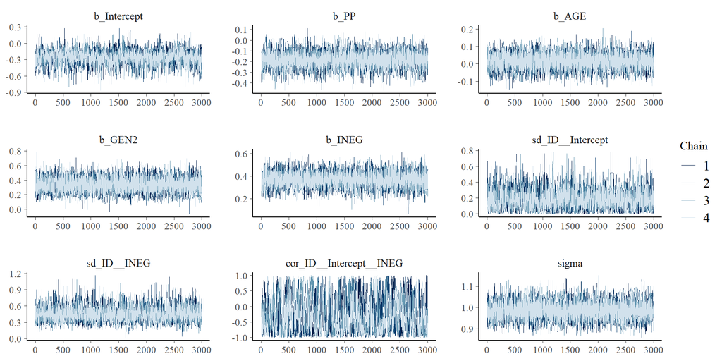

```r
mcmc_plot(fit1_bi, type = "trace")
```

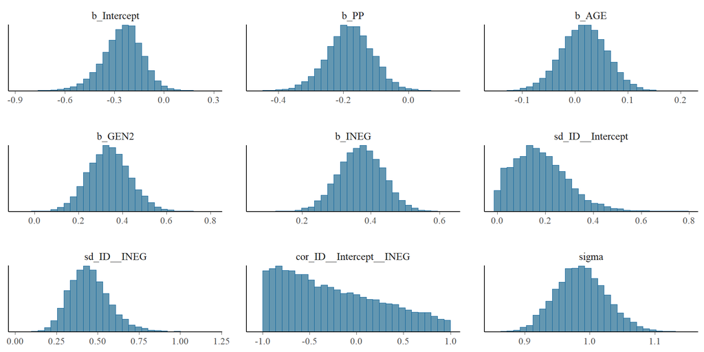

```r
mcmc_plot(fit1_bi, type = "hist")
```

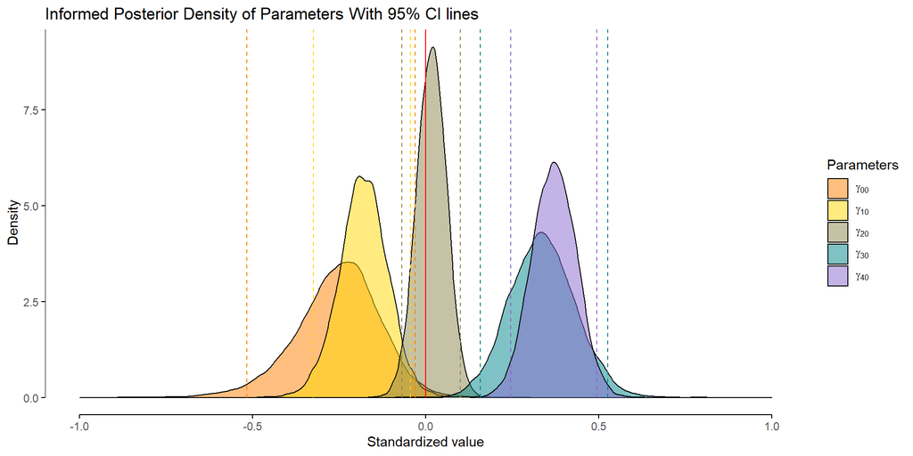

```r
.plotPopulationEffectDensities(fit1_bi, title = "Informed Posterior Density of Parameters With 95% CI lines",
                                xmin = -1, xmax = 1, warmup = warmup)
```

#### 3.1.3.2 Hypothesis tests

##### 3.1.3.2.1 Hypothesis 1: $\gamma_{10}$ < 0

```r
hypothesis1_bni <- brms::hypothesis(fit1_bni, "PP < 0", class = "b")
hypothesis1_bi <- brms::hypothesis(fit1_bi, "PP < 0", class = "b")
tab <- data.frame("Priors" = c("Non-informative", "Informed"))
tab <- cbind(tab, rbind(hypothesis1_bni$hypothesis, hypothesis1_bi$hypothesis))
print(tab)
```

```
##            Priors Hypothesis   Estimate  Est.Error   CI.Lower    CI.Upper
## 1 Non-informative   (PP) < 0 -0.1748152 0.09579309 -0.3330815 -0.01778865
## 2        Informed   (PP) < 0 -0.1805946 0.07029935 -0.2981232 -0.06911164
##   Evid.Ratio Post.Prob Star
## 1   27.36879 0.9647500    *
## 2  154.84416 0.9935833    *
```

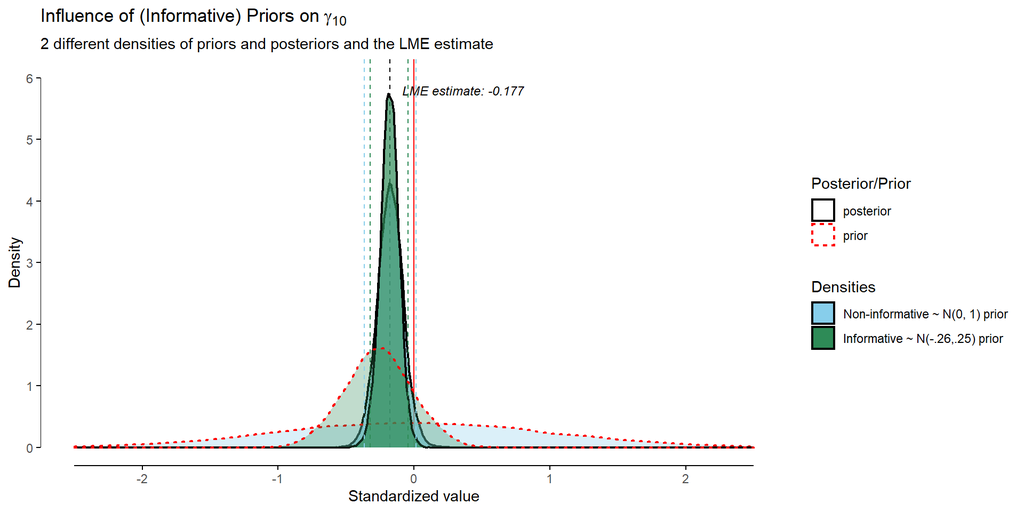

```r
.plotInfluenceOfPriors(coef = "PP", fit1_f, fit1_bni, fit1_bi,
                    title = expression("Influence of (Informative) Priors on" ~ gamma[10]),
                    priors = c("Non-informative ~ N(0, 1) prior", "Informative ~ N(-.26,.25) prior"),
                    xmin = -2.5, xmax = 2.5, ymax = 6)
```

##### 3.1.3.2.2 Hypothesis 6: $\gamma_{40}$ > 0

```r
hypothesis6_bni <- brms::hypothesis(fit1_bni, "INEG > 0", class = "b")
hypothesis6_bi <- brms::hypothesis(fit1_bi, "INEG > 0", class = "b")
tab <- data.frame("Priors" = c("Non-informative", "Informed"))
tab <- cbind(tab, rbind(hypothesis6_bni$hypothesis, hypothesis6_bi$hypothesis))
print(tab)
```

```
##            Priors Hypothesis    Estimate  Est.Error   CI.Lower   CI.Upper
## 1 Non-informative (INEG) > 0 -0.03491348 0.06310898 -0.1369768 0.06850356
## 2        Informed (INEG) > 0  0.37037723 0.06376563  0.2664507 0.47311981
##   Evid.Ratio Post.Prob Star
## 1  0.3958358 0.2835833
## 2        Inf 1.0000000    *
```

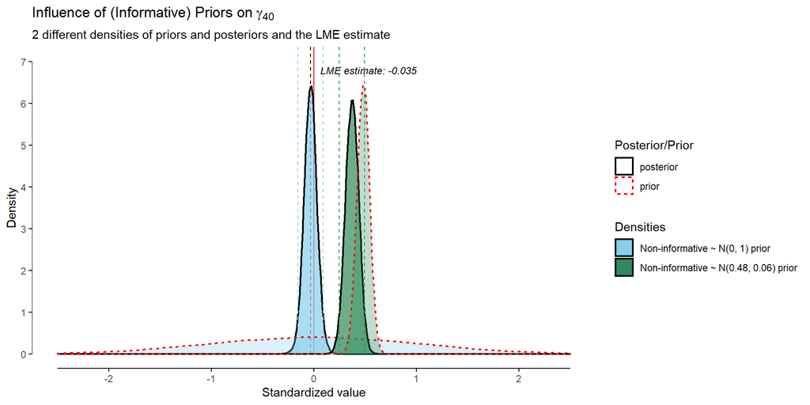

```r
.plotInfluenceOfPriors(coef = "INEG", fit1_f, fit1_bni, fit1_bi,
                    title = expression("Influence of (Informative) Priors on" ~ gamma[40]),
                    priors = c("Non-informative ~ N(0, 1) prior", "Non-informative ~ N(0.48, 0.06) prior"),
                    xmin = -2.5, xmax = 2.5, ymax = 7)
```

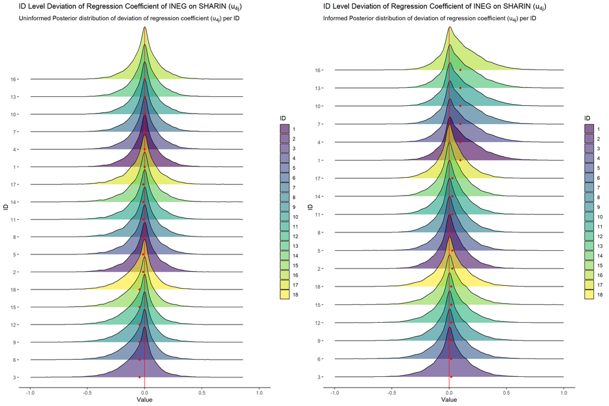

```r
p1 <- .plotIndividualDifferences(independent = "INEG", dependent = "SHAREN", fit = fit1_bni,
                           title = expression(paste("ID Level Deviation of Regression Coefficient of INEG on SHARIN (", u["4j"],")")),
                           subtitle = expression(paste("Uninformed Posterior distribution of deviation of regression coefficient (", u["4j"],") per ID")),
                           xmin = -1, xmax = 1)

p2 <- .plotIndividualDifferences(independent = "INEG", dependent = "SHAREN", fit = fit1_bi,
                           title = expression(paste("ID Level Deviation of Regression Coefficient of INEG on SHARIN (", u["4j"],")")),
                           subtitle = expression(paste("Informed Posterior distribution of deviation of regression coefficient (", u["4j"],") per ID")),
                           xmin = -1, xmax = 1)

grid.arrange(p1, p2, nrow = 1)
```

```r
# Hypothesis 3: Talking more about daily positive events is not associated with psychopathology -> No population effect (PP = 0).
# Hypothesis 8: Intensity of daily positive events is positively associated with sharing -> Positive group effect (IPOS/ID > 0).

model2f <- SHAREN ~ 1 + PP + AGE + GEN + IPOS + (1 + IPOS|ID)
model2b <- SHAREN ~ 0 + Intercept + PP + AGE + GEN + IPOS + (1 + IPOS|ID)
```

## 3.3 Model 3: Ruminating negative events

```r
# Hypothesis 2: Ruminating more about daily negative events is associated with higher psychopathology -> Positive population effect (PP > 0).
# Hypothesis 5: Intensity of daily negative events is positively associated with rumination. -> Positive group effect (INEG/DAY > 0).

model3f <- RUM ~ 1 + PP + AGE + GEN + INEG + (1 + INEG|ID)
model3b <- RUM ~ 0 + Intercept + PP + AGE + GEN + INEG + (1 + INEG|ID)
```

## 3.4 Model 4: Savouring positive events

```r
# Hypothesis 4: Savouring daily positive events is not associated with psychopathology. -> No population effect (PP = 0)
# Hypothesis 7: Intensity of daily positive events is positively associated with savouring. -> Positive group effect (IPOS/DAY > 0)

model4f <- SAV ~ 1 + PP + AGE + GEN + IPOS + (1 + IPOS|ID)
model4b <- SAV ~ 0 + Intercept + PP + AGE + GEN + IPOS + (1 + IPOS|ID)
```

## 3.5 Model 5: Intensity negative events

```r
# Hypothesis 9: Psychopathology is positively associated with the intensity of daily negative events. -> Positive population effect (PP > 0).

model5f <- INEG ~ 1 + PP + AGE + GEN
model5b <- INEG ~ 0 + Intercept + PP + AGE + GEN
```

## 3.6 Model 6: Intensity positive events

```r
# Hypothesis 10: Psychopathology is not associated with the intensity of daily positive events. -> No population effect (PP = 0).

model6f <- IPOS ~ 1 + PP + AGE + GEN
model6b <- IPOS ~ 0 + Intercept + PP + AGE + GEN
```

# 4 Confirmatory Results

```r
types <- c("Frequentist", "Non-informed Bayesian", "Informed Bayesian")

# Model 1 hypothesis 1
model1_model <- c(1, NA, NA)
model1_hyp1_h0 <- c("PP >= 0", NA, NA)
model1_hyp1_h1 <- c("PP < 0", NA, NA)
model1_hyp1_estimates <- c(sum1_f$coefficients["PP", "Estimate"], sum1_bni$fixed["PP", "Estimate"], sum1_bi$fixed["PP", "Estimate"])
model1_hyp1_errors <- c(sum1_f$coefficients["PP", "Std. Error"], sum1_bni$fixed["PP", "Est.Error"], sum1_bi$fixed["PP", "Est.Error"])
model1_hyp1_p <- c(sum1_f$coefficients["PP", 5], NA, NA)
model1_hyp1_pp <- c(NA, hypothesis1_bni$hypothesis$Post.Prob, hypothesis1_bi$hypothesis$Post.Prob)

# Model 1 hypothesis 6
model1_hyp6_h0 <- c("INEG <= 0", NA, NA)
model1_hyp6_h1 <- c("INEG > 0", NA, NA)
model1_hyp6_estimates <- c(sum1_f$coefficients["INEG", "Estimate"], sum1_bni$fixed["INEG", "Estimate"], sum1_bi$fixed["INEG", "Estimate"])
model1_hyp6_errors <- c(sum1_f$coefficients["INEG", "Std. Error"], sum1_bni$fixed["INEG", "Est.Error"], sum1_bi$fixed["INEG", "Est.Error"])
model1_hyp6_p <- c(sum1_f$coefficients["INEG", 5], NA, NA)
model1_hyp6_pp <- c(NA, hypothesis6_bni$hypothesis$Post.Prob, hypothesis6_bi$hypothesis$Post.Prob)

tab <- data.frame(model = c(model1_model, model1_model),
                  h0 = c(model1_hyp1_h0, model1_hyp6_h0),
                  h1 = c(model1_hyp1_h1, model1_hyp6_h1),
                  type = rep(types, 2),
                  estimate = c(model1_hyp1_estimates, model1_hyp6_estimates),
                  error = c(model1_hyp1_errors, model1_hyp6_errors),
                  p = c(model1_hyp1_p, model1_hyp6_p),
                  postprob = c(model1_hyp1_pp, model1_hyp6_pp))
colnames(tab) <- c("Model", "H0", "H1", "Analysis type", "Estimate", "Est.Error", "p(y|H0)", "p(H1|y)")
print(tab)
```

```
##   Model        H0       H1         Analysis type    Estimate  Est.Error
## 1     1   PP >= 0   PP < 0           Frequentist -0.17694550 0.09123873
## 2    NA      <NA>     <NA> Non-informed Bayesian -0.17481524 0.09579309
## 3    NA      <NA>     <NA>     Informed Bayesian -0.18059465 0.07029935
## 4     1 INEG <= 0 INEG > 0           Frequentist -0.03454593 0.05989405
## 5    NA      <NA>     <NA> Non-informed Bayesian -0.03491348 0.06310898
## 6    NA      <NA>     <NA>     Informed Bayesian  0.37037723 0.06376563
##      p(y|H0)   p(H1|y)
## 1 0.07677141        NA
## 2         NA 0.9647500
## 3         NA 0.9935833
## 4 0.57233861        NA
## 5         NA 0.2835833
## 6         NA 1.0000000
```

# 5 Exploratory Analyses

# 6 Exploratory Results